# Technical QC

G Neilson

## Introduction

This is an R Markdown document for the weeekly Quality Control (QC) check from the Illumina EPIC microarray data from the Bipolar Study

Samples are not removed after each QC step, but a record is kept of samples which have already failed previous steps and the results of all tests are provided as output.

## Loading data

```
## [1] "Loading Mset: NCBI_Mset.rdat"
```

```
## [1] "Loading RGset: NCBI_RGset.rdat"
```

### Study Information

**Study:** Bipolar Study

**Description:** Brains for Dementia research.

**Array used:** Illumina EPIC microarray v1.0

**QC done by:**Grant Neilson, The University of Exeter Medical School

**Date of QC:** 07 January 2020

**Sample ages:** 23, 77

**Sample Organ:**

**Sample Tissue:** Frontal_Cortex, Cerrebellum

## QC Information

```
## [1] TRUE
## [1] "Mset and Sample sheet  match"
```

## Check Signal Intensities

The intensity check is the biggest indicator of sample quality. The median methylated signal intensity and unmethylated signal intensity for each sample is calculcated.

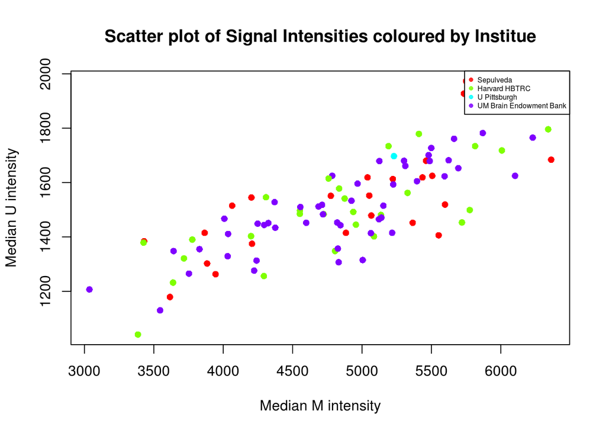

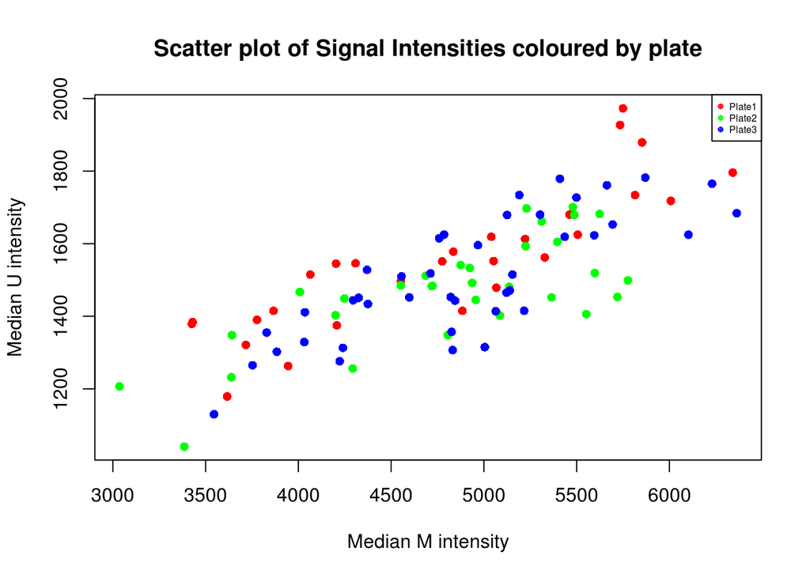

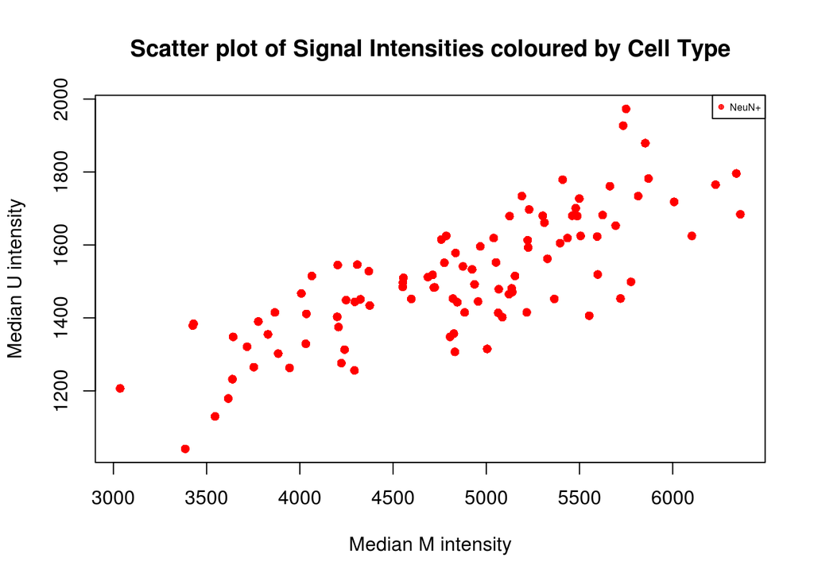

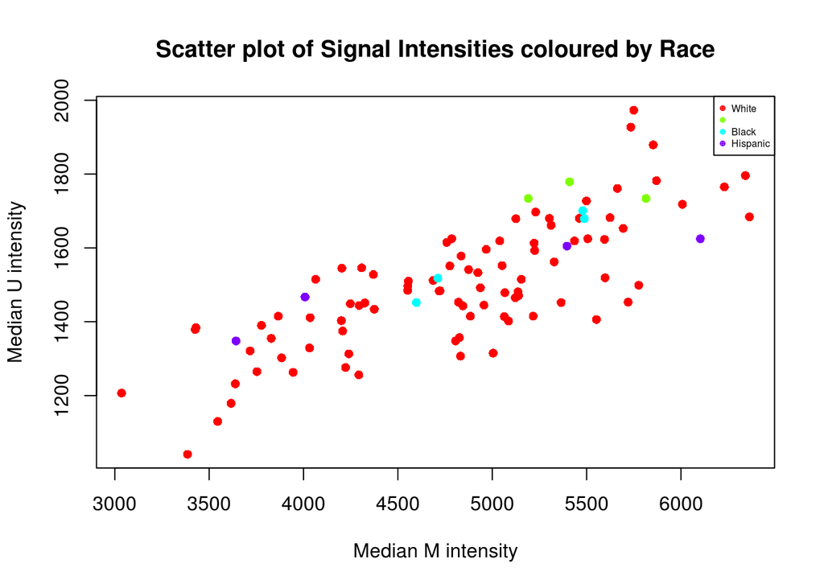

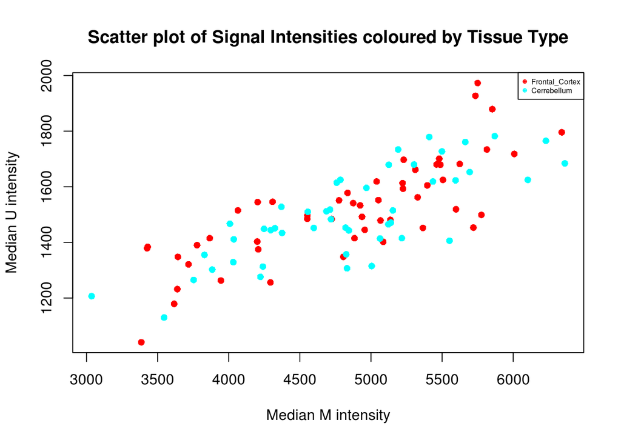

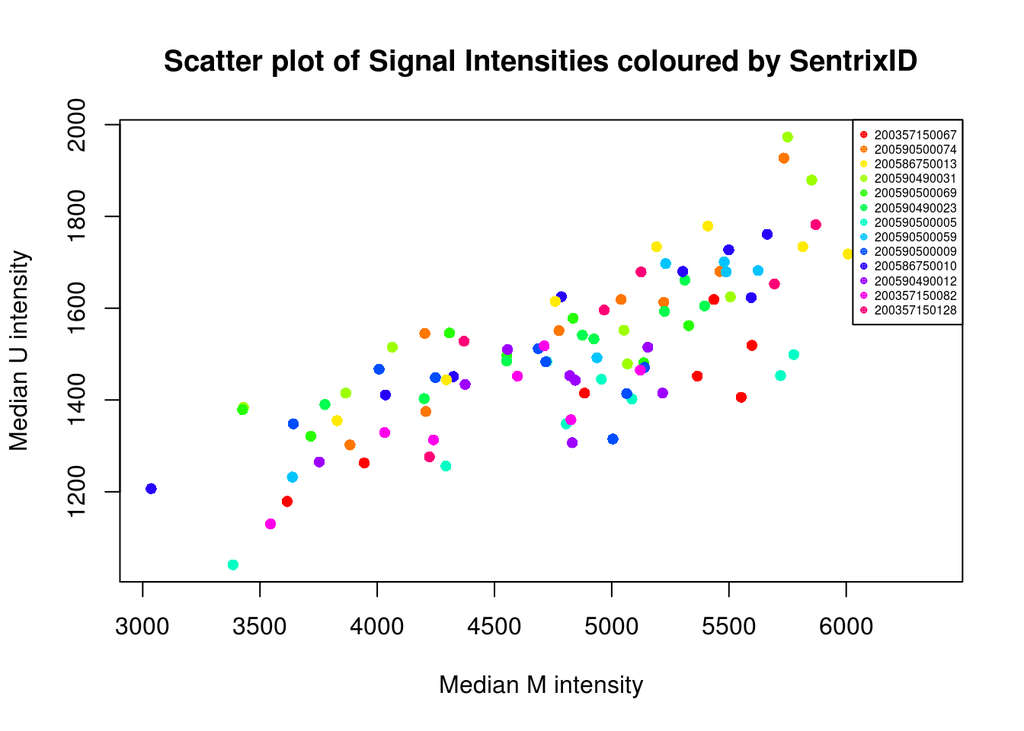

The signal intensities are okay for these samples.

To further investigate the plates we can plot heatmaps of the intensities, shown below.

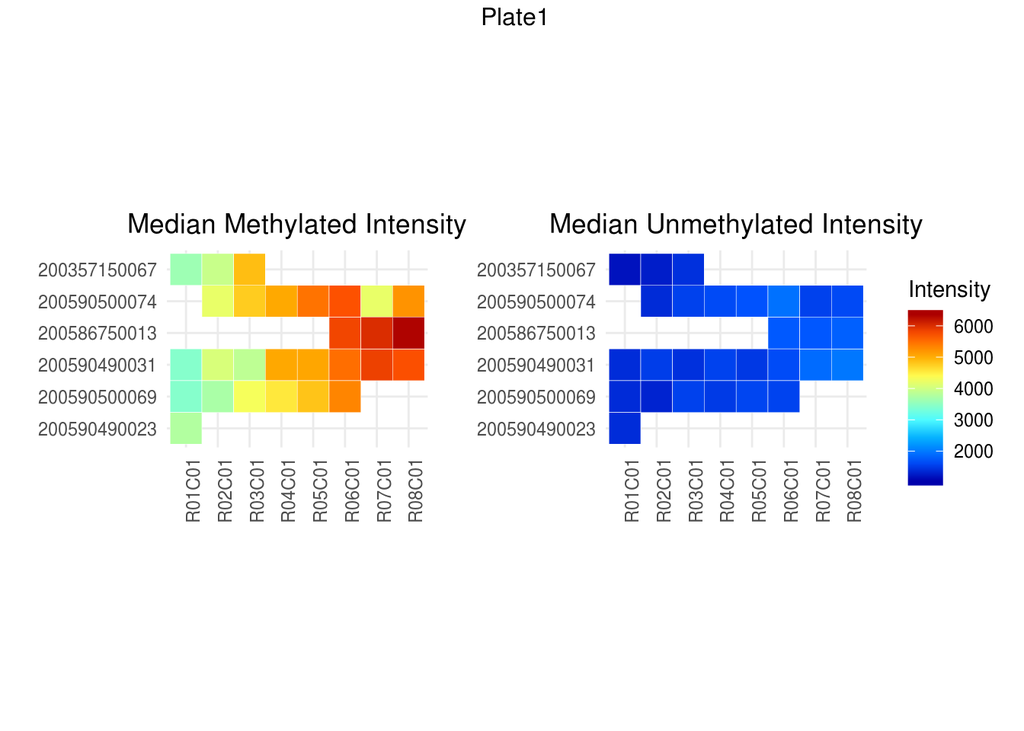

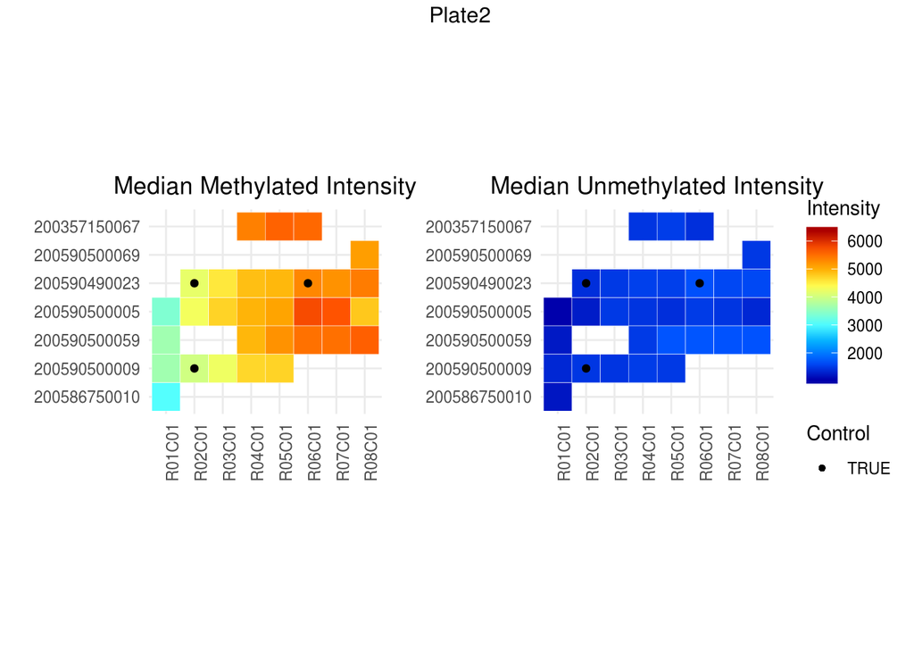

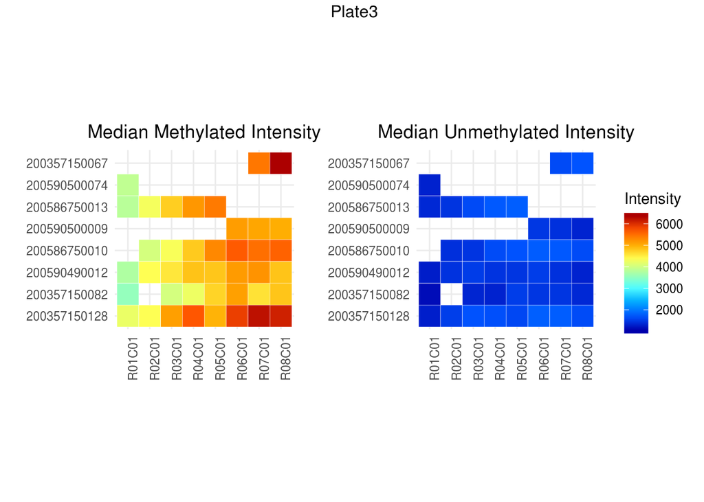

The fully methylated controls have their intensities logged, and saved to FullyMethylatedControlSamples.csv for cross-study comparisions of the scanner.

Although signal intensity is the largest predictor of sample quality, the threshold at which to exclude samples can vary from experiment to experiment - for example, signal intensities can vary slightly depending on tissue type or DNA extraction method. Samples which clearly deviate from the main cluster on the signal intensity plots should be removed. These samples had lower signal intensities than usual

```r
lowintensitysamples<-which(M.median < 1000 | U.median < 1000)
```

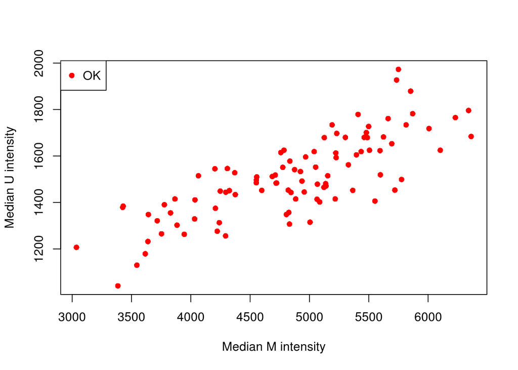

```r
print(Stepsummary)
```

```
##                  Step1
## Failed This Step     0
## Total Failed         0
```

## Bisulphite Conversion

A bisulphite conversion statistic for each sample was calculated, and a histogram of the results plotted.

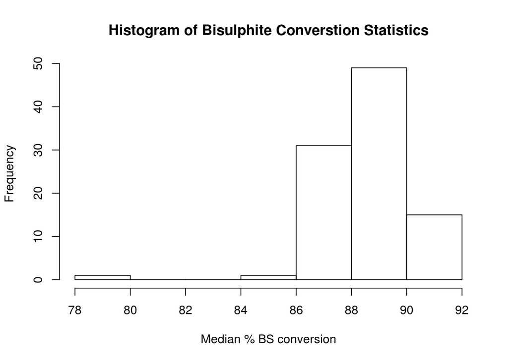

This shows the conversion statistics were generally high. Samples with a conversion < 80% fail the QC, so with this threshold 1 samples fail the QC, and will be removed at a later stage.

```r
print(Stepsummary)
```

```
##                  Step1 Step2
## Failed This Step     0     1
## Total Failed         0     1
```

```r
#
# Chip_ID <- unique(SampleSheet$SentrixID)
# meth_controls_betas <- betas[,SampleSheet$Control]
# mean_betas <- matrix(data = NA, ncol = 1, nrow = ncol(meth_controls_betas))
# rownames(mean_betas)<-colnames(meth_controls_betas)
# colnames(mean_betas) <-c("Mean_beta_value")
# for(i in 1:ncol(meth_controls_betas)){
#   tmp <- meth_controls_betas[,i]
#   mean_betas[i,1] <- median(tmp, na.rm =TRUE)
# }
```